# Redes bayesianas multinomiales

## Introducción

Este documento ajusta una **red bayesiana multinomial (discreta)** sobre la ENMT (Encuesta Nacional de Movilidad y Transporte), para responder preguntas del tipo “¿qué probabilidad hay de que una persona use cierto medio de transporte, dado su nivel de estudios / edad / ingreso?”.

En una red discreta cada nodo es una variable categórica y su parámetro es una **tabla de probabilidad condicional (CPT)**: $P(X_i \mid \text{pa}(X_i))$. Todas las columnas deben ser `factor`.

El flujo es:

1. Cargar los datos ya limpiados por `clean.py` (33 columnas seleccionadas).
2. Definir un dag_jf a mano con conocimiento del dominio.
3. Ajustar las CPTs con `bn.fit()`.
4. Contrastar la estructura propuesta (pruebas de independencia, scores) contra una estructura aprendida automáticamente con `hc()`.
5. Responder preguntas con `cpquery()` (inferencia aproximada por muestreo).

## Paquetes

Instalación manual; el chunk no corre al renderizar.

```r
library(bnlearn)
```

## Datos

`clean_enmt_unam.csv` lo produce `clean.py`: toma `enmt_unam.csv` (698 columnas, codificado en `latin-1`) y se queda con 33 variables — las 22 de frecuencia de uso por medio de transporte (`p1a_1` … `p1a_22`), dos de percepción del transporte público y los sociodemográficos.

Ojo con `stringsAsFactors = TRUE`: aquí **no hace nada**, porque el CSV no tiene ni una columna de texto — todo son códigos numéricos (`sexo` = 1/2, `escol` = 2, …). Sin la conversión explícita del siguiente chunk, todas las columnas entran como `integer` y `bn.fit()` falla, porque una red multinomial exige `factor`.

Variables usadas en el dag_jf:

| Código | Significado |
| --- | --- |
| `edad_1` | Edad de la persona (grupos) |
| `sexo` | Sexo de la persona |
| `escol` | Nivel de escolaridad |
| `estrato` | Estrato de muestreo |
| `h21_1` | Ocupación principal |
| `Tam_loc` | Tamaño de la localidad |
| `ing_fam` | Ingreso familiar |
| `p17_1` | Eficiencia del transporte público (1 = eficiente) |
| `p17_4` | Seguridad del transporte público (1 = seguro) |
| `uso_tp` | **[artificial]** Uso de transporte público (ver abajo) |

```r
data = read.csv("/Users/juanfelipezepeda/Documents/TEC/Javier 3/querysSobreTransporte/data/clean_enmt_unam.csv", stringsAsFactors = TRUE)
head(data)
```

| p1a_1 | p1a_2 | p1a_3 | p1a_4 | p1a_5 | p1a_6 | p1a_7 | p1a_8 | p1a_9 | p1a_10 | p1a_11 | p1a_12 | p1a_13 | p1a_14 | p1a_15 | p1a_16 | p1a_17 | p1a_18 | p1a_19 | p1a_20 | p1a_21 | p1a_22 | p17_1 | p17_4 | sexo | edad_1 | escol | cond_act | h21_1 | Tam_loc | … |
| --- | --- | --- | --- | --- | --- | --- | --- | --- | --- | --- | --- | --- | --- | --- | --- | --- | --- | --- | --- | --- | --- | --- | --- | --- | --- | --- | --- | --- | --- | --- |
| 3 | 3 | 3 | 3 | 3 | 3 | 3 | 3 | 3 | 3 | 3 | 2 | 3 | 3 | 3 | 3 | 3 | 3 | 3 | 3 | 3 | 3 | 1 | 1 | 2 | 3 | 2 | 2 | 9 | 1 | … |
| 3 | 3 | 3 | 3 | 3 | 3 | 3 | 3 | 3 | 3 | 3 | 2 | 3 | 3 | 3 | 3 | 3 | 3 | 3 | 3 | 3 | 3 | 1 | 2 | 2 | 5 | 4 | 2 | 12 | 1 | … |
| 3 | 2 | 3 | 3 | 3 | 3 | 3 | 3 | 3 | 3 | 3 | 1 | 3 | 3 | 3 | 3 | 3 | 3 | 3 | 3 | 3 | 3 | 1 | 1 | 1 | 4 | 4 | 1 | 1 | 3 | … |
| 3 | 2 | 3 | 1 | 2 | 1 | 2 | 2 | 2 | 3 | 3 | 1 | 3 | 3 | 3 | 3 | 3 | 3 | 3 | 3 | 3 | 3 | 1 | 2 | 2 | 2 | 5 | 1 | 7 | 1 | … |
| 3 | 3 | 3 | 1 | 3 | 3 | 3 | 3 | 3 | 3 | 3 | 1 | 3 | 3 | 3 | 3 | 3 | 3 | 3 | 3 | 3 | 3 | 1 | 2 | 2 | 6 | 2 | 1 | 7 | 4 | … |
| 3 | 3 | 3 | 2 | 2 | 2 | 2 | 1 | 3 | 3 | 3 | 1 | 3 | 3 | 3 | 2 | 3 | 3 | 3 | 3 | 2 | 3 | 1 | 2 | 1 | 3 | 4 | 1 | 13 | 2 | … |

### Variable artificial `uso_tp`

La pregunta que queremos responder — *¿qué tan probable es que alguien se mueva en transporte público?* — no tiene una sola columna que la conteste. La ENMT registra la frecuencia de uso **modo por modo**: `p1a_1` … `p1a_7` son los siete medios públicos (tren, metro, tranvía, camión/microbús, taxi, combi, …), cada uno codificado `1` = Cotidianamente, `2` = Ocasionalmente, `3` = Nunca, más `8` = NS y `9` = NC.

Meter los siete como nodos separados no sirve: multiplicaría el dag_jf y dejaría la respuesta repartida en siete CPTs. Se colapsan en una sola variable ordinal.

El truco está en que la codificación original ya es un orden: `1 < 2 < 3` es “más frecuente < menos frecuente”. Así que **el mínimo por renglón es el modo público que la persona más usa**, y con eso el valor agregado se lee igual que los originales:

- `Cotidiano` — usa al menos un medio público cotidianamente (algún `p1a_i == 1`).
- `Ocasional` — ninguno cotidiano, pero al menos uno ocasional.
- `Nunca` — contestó “Nunca” a los siete.

Los `8`/`9` se vuelven `NA` **antes** del mínimo, no después: son no-respuestas sobre *un* modo, y no deben invalidar a la persona si contestó los otros seis. Solo si los siete son NS/NC queda `NA` — pasa en 1 de 1191 renglones. (Ese `min()` sobre puros `NA` devuelve `Inf` con warning; de ahí las dos líneas de limpieza.)

```r
frec = as.matrix(data[, paste0("p1a_", 1:7)])
frec[frec >= 8] = NA                                  # 8 = NS, 9 = NC

mejor = suppressWarnings(apply(frec, 1, min, na.rm = TRUE))
mejor[is.infinite(mejor)] = NA                        # los 7 modos sin respuesta

data$uso_tp = factor(mejor, levels = 1:3,
                     labels = c("Cotidiano", "Ocasional", "Nunca"))

table(data$uso_tp, useNA = "ifany")
```

```
Cotidiano Ocasional     Nunca      <NA>
      651       396       143         1
```

Queda razonablemente balanceada (651 / 396 / 143), que es justo lo que se necesita para que las CPTs condicionadas no salgan huecas.

Se recorta a los 10 nodos del dag_jf y se convierten a `factor`. Las dos cosas son necesarias: `bn.fit()` valida el data frame **completo**, así que aunque el dag_jf no incluya `p1a_1` ni `Pondi2`, basta con que sigan en `data` para que truene. (`Pondi2` además es el factor de expansión muestral: un número de verdad, no una categoría.) Nótese que los `p1a_1` … `p1a_7` **no** entran: ya están resumidos dentro de `uso_tp`.

También se tira el único renglón con `uso_tp = NA`: `bn.fit()` no acepta faltantes, y 1 de 1191 no cambia nada.

```r
nodos = c("edad_1", "estrato", "escol", "sexo", "h21_1",
          "Tam_loc", "ing_fam", "p17_1", "p17_4", "uso_tp")

data = data[, nodos]
data = data[!is.na(data$uso_tp), ]
data[] = lapply(data, factor)
str(data)
```

```
'data.frame':   1190 obs. of  10 variables:
 $ edad_1 : Factor w/ 6 levels "2","3","4","5",..: 2 4 3 1 5 2 6 4 5 3 ...
 $ estrato: Factor w/ 16 levels "11","12","13",..: 9 9 7 5 16 10 13 2 2 9 ...
 $ escol  : Factor w/ 6 levels "1","2","3","4",..: 2 4 4 5 2 4 3 1 2 4 ...
 $ sexo   : Factor w/ 2 levels "1","2": 2 2 1 2 2 1 1 2 1 1 ...
 $ h21_1  : Factor w/ 18 levels "-1","1","2","3",..: 10 13 2 8 8 14 13 3 13 8 ...
 $ Tam_loc: Factor w/ 4 levels "1","2","3","4": 1 1 3 1 4 2 1 2 2 1 ...
 $ ing_fam: Factor w/ 8 levels "0","2","3","4",..: 3 8 3 1 3 8 3 6 5 4 ...
 $ p17_1  : Factor w/ 2 levels "1","2": 1 1 1 1 1 1 1 1 1 1 ...
 $ p17_4  : Factor w/ 2 levels "1","2": 1 2 1 2 2 2 1 1 1 2 ...
 $ uso_tp : Factor w/ 3 levels "Cotidiano","Ocasional",..: 3 3 2 1 1 2 2 2 2 3 ...
```

## Estructura de la red

Se construye el dag_jf en dos pasos: primero un grafo vacío con los nodos, después se le asignan los arcos. Es la alternativa a `model2network()` cuando hay muchos arcos y conviene listarlos como tabla.

Los 10 nodos son exactamente los que aparecen en `arc_set`: si `empty.graph()` declarara alguno de más o de menos, `arcs(dag_jf) = arc_set` fallaría.

```r
dag_jf = empty.graph(nodes = c("edad_1", "estrato", "escol", "sexo", "h21_1",
                            "Tam_loc", "ing_fam", "p17_1", "p17_4", "uso_tp"))
```

Cada renglón de la matriz es un arco `from → to`. Con `byrow = TRUE` la matriz se llena por renglones, así que se lee como una lista de pares. La estructura propuesta es:

- `edad_1 → escol`, `estrato → escol` — la escolaridad depende de la edad y del estrato socioeconómico.
- `escol → h21_1`, `sexo → h21_1` — la ocupación depende de la escolaridad y del sexo.
- `h21_1 → ing_fam`, `Tam_loc → ing_fam` — el ingreso familiar depende de la ocupación y del tamaño de localidad.
- `Tam_loc → p17_1`, `Tam_loc → p17_4` — la percepción de eficiencia y seguridad del transporte público depende del tamaño de la localidad.
- `ing_fam → uso_tp`, `p17_1 → uso_tp`, `p17_4 → uso_tp` — el uso del transporte público depende del ingreso (quien puede pagar auto tiene con qué sustituirlo) y de qué tan bien se le percibe.

Es decir, los sociodemográficos influyen en el uso del transporte público solo de forma **indirecta**, vía ingreso y percepción. En particular `Tam_loc` llega a `uso_tp` únicamente por los tres caminos `Tam_loc → ing_fam → uso_tp`, `Tam_loc → p17_1 → uso_tp` y `Tam_loc → p17_4 → uso_tp`: se decidió **no** poner un arco directo `Tam_loc → uso_tp` para mantener la CPT en 3 padres (3 × 8·2·2 = 96 parámetros en vez de 384, que con 1190 filas ya deja celdas huecas).

```r
arc_set = matrix(c("edad_1", "escol",
                   "estrato", "escol",
                   "escol", "h21_1",
                   "sexo", "h21_1",
                   "h21_1", "ing_fam",
                   "Tam_loc", "ing_fam",
                   "Tam_loc", "p17_1",
                   "Tam_loc", "p17_4",
                   "ing_fam", "uso_tp",
                   "p17_1", "uso_tp",
                   "p17_4", "uso_tp"
                   ),
                 byrow = TRUE, ncol = 2,
                 dimnames = list(NULL, c("from", "to")))
```

`arcs(dag_jf) =` inyecta los arcos y valida que el resultado siga siendo acíclico. Imprimir `dag_jf` muestra el modelo, los arcos y el tamaño del espacio de parámetros.

```r
arcs(dag_jf) = arc_set
dag_jf
```

```
  Random/Generated Bayesian network

  model:
   [edad_1][estrato][sexo][Tam_loc][escol|edad_1:estrato][p17_1|Tam_loc]
   [p17_4|Tam_loc][h21_1|escol:sexo][ing_fam|h21_1:Tam_loc]
   [uso_tp|ing_fam:p17_1:p17_4]
  nodes:                                 10
  arcs:                                  11
    undirected arcs:                     0
    directed arcs:                       11
  average markov blanket size:           3.40
  average neighbourhood size:            2.20
  average branching factor:              1.10

  generation algorithm:                  Empty
```

Visualizacion de grafico de nodos con `graphviz`

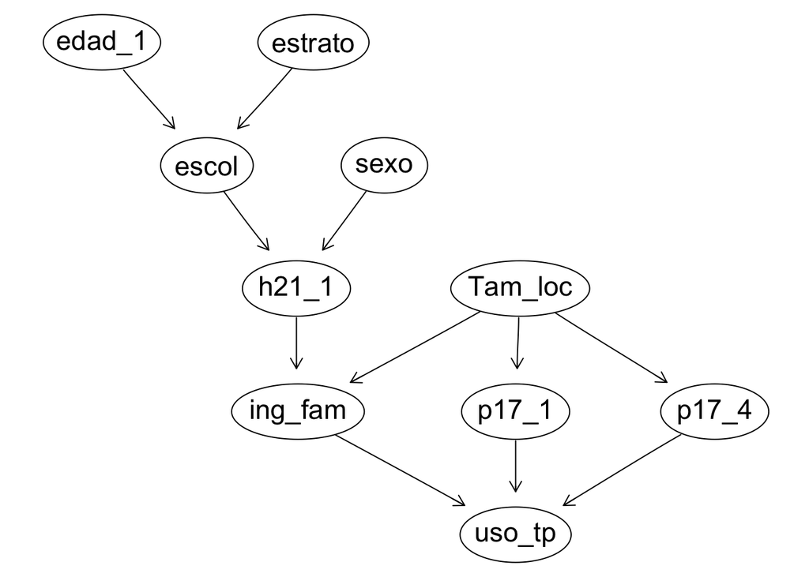

```r
graphviz.plot(dag_jf, shape = "ellipse")
```

```r
score(dag_jf, data = data, type = 'bic')
```

```
[1] -20609.34
```

```r
score(dag_jf, data = data, type = 'aic')
```

```
[1] -17346.88
```

```r
best_dag = hc(data)
best_dag
```

```
  Bayesian network learned via Score-based methods

  model:
   [edad_1][estrato][h21_1][ing_fam][uso_tp][escol|edad_1][Tam_loc|estrato]
   [sexo|escol][p17_1|Tam_loc][p17_4|p17_1]
  nodes:                                 10
  arcs:                                  5
    undirected arcs:                     0
    directed arcs:                       5
  average markov blanket size:           1.00
  average neighbourhood size:            1.00
  average branching factor:              0.50

  learning algorithm:                    Hill-Climbing
  score:                                 BIC (disc.)
  penalization coefficient:              3.540854
  tests used in the learning procedure:  90
  optimized:                             TRUE
```

## Ajuste de parámetros

Con la estructura fija, `bn.fit()` estima las CPTs. `method = "mle"` usa máxima verosimilitud, es decir, frecuencias relativas observadas. La alternativa es `method = "bayes"`, que suaviza con un prior — preferible cuando alguna combinación de padres tiene pocas observaciones (con 1191 filas y padres de varios niveles, aquí es un riesgo real: las CPTs con celdas vacías salen `NaN`).

```r
bn_mle = bn.fit(dag_jf, data = data, method = "mle")
bn_mle
```

```
  Bayesian network parameters

  Parameters of node edad_1 (multinomial distribution)

Conditional probability table:
          2          3          4          5          6          7
0.16470588 0.25378151 0.23613445 0.15126050 0.10084034 0.09327731

  Parameters of node estrato (multinomial distribution)

Conditional probability table:
         11         12         13         14         21         22         23
0.12100840 0.06050420 0.06050420 0.05042017 0.15882353 0.04033613 0.04033613
        24         31         32         33         34         41         42
0.02016807 0.16134454 0.04033613 0.03445378 0.02016807 0.08067227 0.04033613
        43         44
0.04033613 0.03025210

  Parameters of node escol (multinomial distribution)

Conditional probability table:

, , estrato = 11

     edad_1
escol          2          3          4          5          6          7
    1 0.00000000 0.08333333 0.09090909 0.06896552 0.12500000 0.00000000
    2 0.09090909 0.19444444 0.15151515 0.27586207 0.25000000 0.37500000
    3 0.40909091 0.33333333 0.48484848 0.37931034 0.50000000 0.37500000
    4 0.40909091 0.25000000 0.18181818 0.27586207 0.06250000 0.00000000
    5 0.09090909 0.13888889 0.09090909 0.00000000 0.06250000 0.25000000
    8 0.00000000 0.00000000 0.00000000 0.00000000 0.00000000 0.00000000

, , estrato = 12

     edad_1
escol          2          3          4          5          6          7
    1 0.00000000 0.00000000 0.04761905 0.09090909 0.16666667 0.60000000
    2 0.00000000 0.22222222 0.33333333 0.36363636 0.83333333 0.40000000
    3 0.36363636 0.33333333 0.61904762 0.45454545 0.00000000 0.00000000
```

[output cut: 417 more lines]

[output not shown]

```
  Parameters of node escol (multinomial distribution)

Conditional probability table:

, , estrato = 11

     edad_1
escol          2          3          4          5          6          7
    1 0.00000000 0.08333333 0.09090909 0.06896552 0.12500000 0.00000000
    2 0.09090909 0.19444444 0.15151515 0.27586207 0.25000000 0.37500000
    3 0.40909091 0.33333333 0.48484848 0.37931034 0.50000000 0.37500000
    4 0.40909091 0.25000000 0.18181818 0.27586207 0.06250000 0.00000000
    5 0.09090909 0.13888889 0.09090909 0.00000000 0.06250000 0.25000000
    8 0.00000000 0.00000000 0.00000000 0.00000000 0.00000000 0.00000000

, , estrato = 12

     edad_1
escol          2          3          4          5          6          7
    1 0.00000000 0.00000000 0.04761905 0.09090909 0.16666667 0.60000000
    2 0.00000000 0.22222222 0.33333333 0.36363636 0.83333333 0.40000000
    3 0.36363636 0.33333333 0.61904762 0.45454545 0.00000000 0.00000000
    4 0.63636364 0.27777778 0.00000000 0.09090909 0.00000000 0.00000000
    5 0.00000000 0.16666667 0.00000000 0.00000000 0.00000000 0.00000000
    8 0.00000000 0.00000000 0.00000000 0.00000000 0.00000000 0.00000000

, , estrato = 13

     edad_1
escol          2          3          4          5          6          7
    1 0.00000000 0.07692308 0.05000000 0.12500000 0.66666667 1.00000000
    2 0.07692308 0.00000000 0.15000000 0.00000000 0.33333333 0.00000000
    3 0.46153846 0.38461538 0.70000000 0.62500000 0.00000000 0.00000000
    4 0.46153846 0.53846154 0.10000000 0.25000000 0.00000000 0.00000000
    5 0.00000000 0.00000000 0.00000000 0.00000000 0.00000000 0.00000000
    8 0.00000000 0.00000000 0.00000000 0.00000000 0.00000000 0.00000000

, , estrato = 14

     edad_1
```

[output cut: 124 more lines]

```
    3 0.57142857 0.35714286 0.37500000 0.27272727 0.00000000 0.50000000
    4 0.28571429 0.50000000 0.50000000 0.27272727 0.50000000 0.00000000
    5 0.14285714 0.00000000 0.00000000 0.00000000 0.00000000 0.00000000
    8 0.00000000 0.00000000 0.00000000 0.00000000 0.00000000 0.00000000

, , estrato = 44

     edad_1
escol          2          3          4          5          6          7
    1 0.00000000 0.14285714 0.14285714 0.00000000 0.37500000 0.50000000
    2 0.00000000 0.42857143 0.28571429 0.66666667 0.50000000 0.25000000
    3 0.42857143 0.14285714 0.42857143 0.33333333 0.00000000 0.25000000
    4 0.57142857 0.28571429 0.14285714 0.00000000 0.12500000 0.00000000
    5 0.00000000 0.00000000 0.00000000 0.00000000 0.00000000 0.00000000
    8 0.00000000 0.00000000 0.00000000 0.00000000 0.00000000 0.00000000
```

[output not shown]

## Pruebas de independencia condicional

`ci.test()` prueba $H_0$: los dos primeros argumentos son independientes dado el tercero. Un p-valor grande apoya la independencia, y por tanto la ausencia de un arco directo entre ambos. Sirve para justificar la estructura propuesta.

`test = 'mi'` usa información mutua (razón de verosimilitudes); `test = 'x2'` usa la ji-cuadrada de Pearson. Ambas son asintóticamente equivalentes, así que se corren las dos como verificación cruzada.

```r
set.seed(1)
ci.test('uso_tp', 'h21_1', c('p17_1','p17_4'), test = 'mi', data = data)
```

```
    Mutual Information (disc.)

data:  uso_tp ~ h21_1 | p17_1 + p17_4
mi = 219.36, df = 136, p-value = 7.744e-06
alternative hypothesis: true value is greater than 0
```

```r
ci.test('uso_tp', 'h21_1', c('p17_1','p17_4'), test = 'x2', data = data)
```

```
    Pearson's X^2

data:  uso_tp ~ h21_1 | p17_1 + p17_4
x2 = 194.87, df = 136, p-value = 0.0007009
alternative hypothesis: true value is greater than 0
```

```r
ci.test('uso_tp', 'h21_1', c('p17_1','p17_4'), test = 'mc-x2', data = data)
```

[output not shown]

**Aquí se condiciona en una sola variable en lugar de dos.**

```r
ci.test('uso_tp', 'h21_1', 'p17_1', test = 'x2', data = data)
```

```
    Pearson's X^2

data:  uso_tp ~ h21_1 | p17_1
x2 = 128.64, df = 68, p-value = 1.267e-05
alternative hypothesis: true value is greater than 0
```

```r
ci.test('uso_tp', 'h21_1', 'p17_4', test = 'x2', data = data)
```

```
    Pearson's X^2

data:  uso_tp ~ h21_1 | p17_4
x2 = 117.91, df = 68, p-value = 0.0001671
alternative hypothesis: true value is greater than 0
```

> Hay evidencia fuerte (x² = 194.9, df = 136, p ≈ 0.0007) de que el uso del transporte público se relaciona con la ocupación, aun controlando por la eficiencia y la seguridad percibidas — y por separado con cada una (p ≈ 1e-5 y p ≈ 2e-4). La asociación es consistente con el modelo propuesto, en el que la ocupación influye sobre el uso del transporte público a través del ingreso familiar.

Con `p1a_12` (automóvil particular) como nodo respuesta esta misma prueba salía apenas al borde (p ≈ 0.04 por permutación). Al agregar los siete modos públicos en `uso_tp` la señal es mucho más limpia: colapsar reduce los grados de libertad y concentra la frecuencia en tres celdas en lugar de repartirla.

## Respuesta a la pregunta

> **¿Cuál es la probabilidad de que personas con altos ingresos en localidades grandes se muevan en transporte público si es eficiente y seguro?**

Traducida a evidencia sobre la red:

| Condición | Variable | Valor |
| --- | --- | --- |
| altos ingresos | `ing_fam` | `7` (5–6 SM) u `8` (más de 5 SM) |
| localidad grande | `Tam_loc` | `1` (100 000+ habitantes) |
| es eficiente | `p17_1` | `1` (Eficiente) |
| es seguro | `p17_4` | `1` (Seguro) |

Aquí se ajusta con `method = "bayes"` y no con `"mle"`: la evidencia es una combinación específica de cuatro condiciones, y con MLE varias celdas de la CPT salen `0` o `NaN` por falta de observaciones, lo que sesga el muestreo.

`method = "lw"` (*likelihood weighting*) en vez del muestreo por rechazo por lo mismo — la evidencia es rara (61 de 1190 filas la cumplen), así que rechazar descartaría casi todas las simulaciones. `lw` fija la evidencia y pondera. Exige pasarla como `list()`, lo cual además permite `ing_fam = c("7", "8")` para aceptar cualquiera de los dos niveles altos.

```r
bn = bn.fit(dag_jf, data = data, method = "bayes")

evidencia = list(ing_fam = c("7", "8"), Tam_loc = "1", p17_1 = "1", p17_4 = "1")

set.seed(42)
cpquery(bn, event = (uso_tp == "Cotidiano"), evidence = evidencia,
        method = "lw", n = 10^6)
```

```
[1] 0.5897955
```

Es decir, **≈ 59 %** usa transporte público *cotidianamente* bajo esas condiciones. Como `uso_tp` tiene tres niveles, la misma variable contesta también la lectura laxa de “se mueve en transporte público” (cotidiana **u** ocasionalmente):

```r
set.seed(42)
cpquery(bn, event = (uso_tp != "Nunca"), evidence = evidencia,
        method = "lw", n = 10^6)
```

```
[1] 0.8218228
```

≈ 82 %. Y el contraste que le da sentido al “si es eficiente y seguro” — misma gente, mismo tamaño de localidad, pero con el transporte percibido como ineficiente e inseguro:

```r
set.seed(42)
cpquery(bn, event = (uso_tp == "Cotidiano"),
        evidence = list(ing_fam = c("7", "8"), Tam_loc = "1",
                        p17_1 = "2", p17_4 = "2"),
        method = "lw", n = 10^6)
```

```
[1] 0.5472146
```

≈ 55 %. La diferencia es de apenas ~4 puntos: para este grupo, la percepción de calidad del transporte público **mueve poco la aguja**. Contraintuitivo, pero coherente con el dag_jf — en localidades grandes el uso cotidiano está sostenido por la disponibilidad de la red, no por lo bien que se le califique.

Contraste contra los datos crudos, para verificar que la red no está inventando:

```r
sub = subset(data, ing_fam %in% c("7", "8") & Tam_loc == "1" &
                   p17_1 == "1" & p17_4 == "1")
nrow(sub)
```

```
[1] 61
```

```r
table(sub$uso_tp)
```

```
Cotidiano Ocasional     Nunca
       37        14        10
```

```r
prop.table(table(sub$uso_tp))
```

```
Cotidiano Ocasional     Nunca
0.6065574 0.2295082 0.1639344
```